**City College of San Francisco**

MATH 108 - Foundations of Data Science

# Lecture 30: Linear Regression

Associated Textbook Sections: [15.2](https://inferentialthinking.com/chapters/15/2/Regression_Line.html)

## Set Up the Notebook

```python
from datascience import *
import numpy as np
%matplotlib inline
import matplotlib.pyplot as plots
plots.style.use('fivethirtyeight')

# Some functions for plotting. You don't have to understand how any
# of the functions in this cell work, since they use things we
# haven't learned about in this course.

def resize_window(lim=3.5):
    plots.xlim(-lim, lim)
    plots.ylim(-lim, lim)

def draw_line(slope=0, intercept=0, x=make_array(-4, 4), color='r'):
    y = x*slope + intercept
    plots.plot(x, y, color=color)

def draw_vertical_line(x_position, color='black'):
    x = make_array(x_position, x_position)
    y = make_array(-4, 4)
    plots.plot(x, y, color=color)

def make_correlated_data(r):
    x = np.random.normal(0, 1, 1000)
    z = np.random.normal(0, 1, 1000)
    y = r*x + (np.sqrt(1-r**2))*z
    return x, y

def r_scatter(r):
    """Generate a scatter plot with a correlation approximately r"""
    plots.figure(figsize=(5,5))
    x, y = make_correlated_data(r)
    plots.scatter(x, y, color='darkblue', s=20)
    plots.xlim(-4, 4)
    plots.ylim(-4, 4)

def r_table(r):
    """
    Generate a table of 1000 data points with a correlation approximately r
    """
    np.random.seed(8)
    x, y = make_correlated_data(r)
    return Table().with_columns('x', x, 'y', y)

def nn_prediction_galton(h):
    """Return a prediction of the height of a child
    whose parents have a midparent height of h.

    The prediction is the average height of the children
    whose midparent height is in the range h plus or minus 0.5 inches.
    """
    neighbors = heights.where(
        'MidParent', are.between(h - 0.5, h + 0.5))
    return np.mean(neighbors.column('Child'))
```

## Prediction

```python
galton = Table.read_table('data/galton.csv')
heights = Table().with_columns(
    'MidParent', galton.column('midparentHeight'),
    'Child', galton.column('childHeight'))
```

### Galton's Heights (`child` vs. `midParent`)

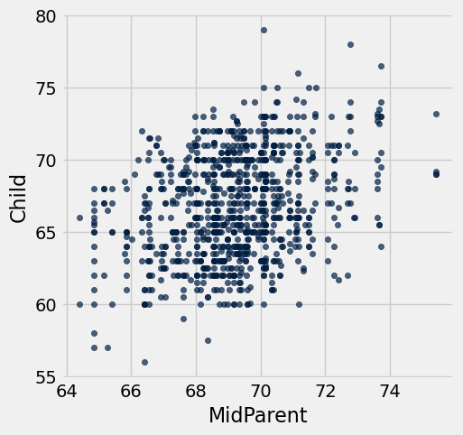

```python
heights.scatter('MidParent')
```

- Oval shaped
- Moderate positive correlation
- How can we predict child height from mid-parent height?

### Galton's Heights (within 0.5 of `midParentHeight`)

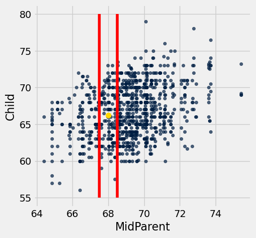

```python
heights.scatter('MidParent')
plots.plot([68-0.5, 68-0.5], [55, 80], color="red", lw=4)
plots.plot([68+0.5, 68+0.5], [55, 80], color="red", lw=4)
plots.scatter(68, nn_prediction_galton(68), color="gold", s=60, zorder=3)
plots.show()
```

### Galton's Heights (predictions)

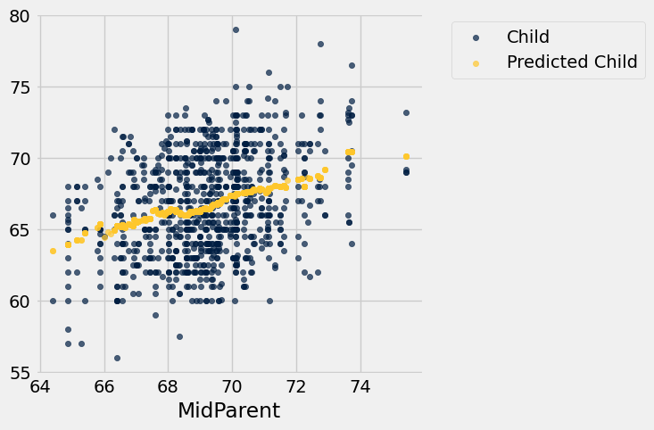

```python
predicted_child = heights.apply(nn_prediction_galton, 'MidParent')
heights_with_predictions = heights.with_column('Predicted Child', predicted_child)
heights_with_predictions.scatter('MidParent')
```

### Nearest Neighbor Regression

- A method for prediction:
  - Group each x with similar (nearby) x values
  - Average the corresponding y values for each group
  - For each x value, the prediction is the average of the y values in its nearby group.
- The graph of these predictions is the "graph of averages".
- If the association between x and y is linear, then points in the graph of averages tend to fall on a line.

### Where is the prediction line? (`r=0.99`)

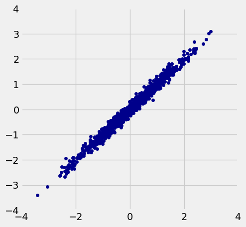

```python
r_scatter(0.99)
```

### Where is the prediction line? (`r=0`)

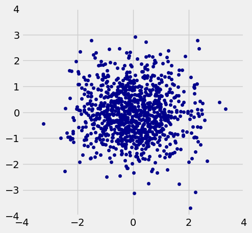

```python
r_scatter(0)
```

### Demo: Prediction lines

Identify the best fit line in relation to the nearest neighbor predictions with data showing an r value of 0.99.

```python
example = r_table(0.99)
example.show(3)
```

| x | y |
| --- | --- |
| 0.0912047 | -0.0680119 |
| 1.09128 | 1.04391 |
| -1.94697 | -1.88316 |

... (997 rows omitted)

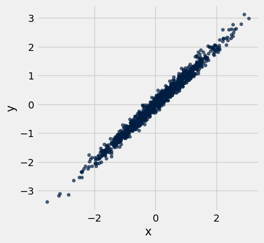

```python
example.scatter('x', 'y')
```

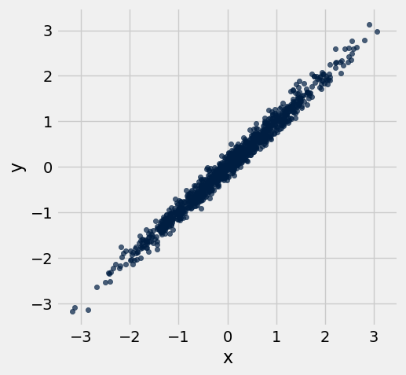

```python
example.scatter('x', 'y')
resize_window()
```

```python
def nn_prediction_example(x_val):
    """ Predicts y-value for x based on the example table """
    neighbors = example.where('x', are.between(x_val - .25, x_val + .25))
    return np.mean(neighbors.column('y'))
```

```python
nn_prediction_example(-2.25)
```

```
-2.1476337989800522
```

```python
example = example.with_columns(
    'Predicted y',
    example.apply(nn_prediction_example, 'x'))
```

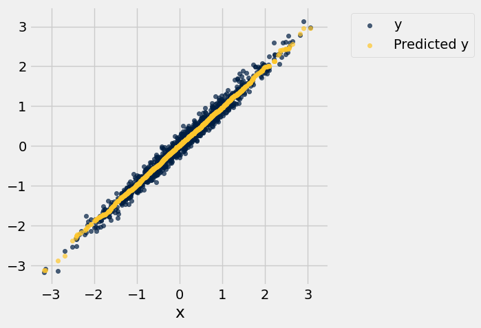

```python
example.scatter('x')
resize_window()
```

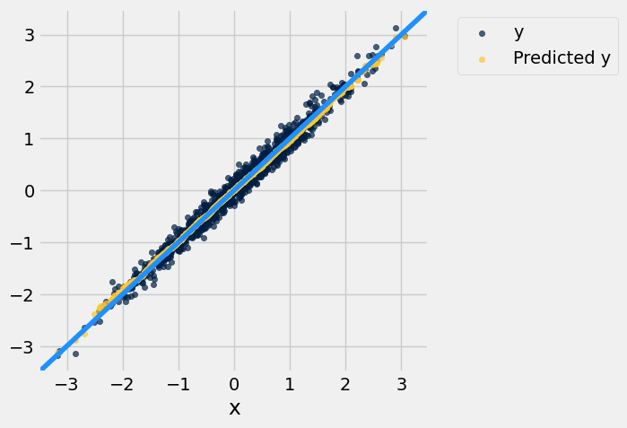

```python
example.scatter('x')
draw_line(slope=1, color='dodgerblue')
resize_window()
```

Identify the best fit line in relation to the nearest neighbor predictions with data showing an r value of 0.

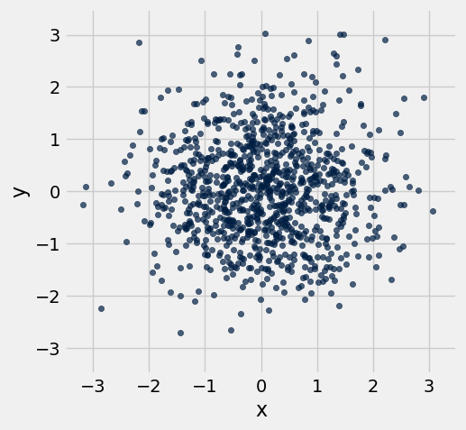

```python
example = r_table(0)
example.scatter('x', 'y')
resize_window()
```

```python
example = example.with_columns(
    'Predicted y',
    example.apply(nn_prediction_example, 'x'))
```

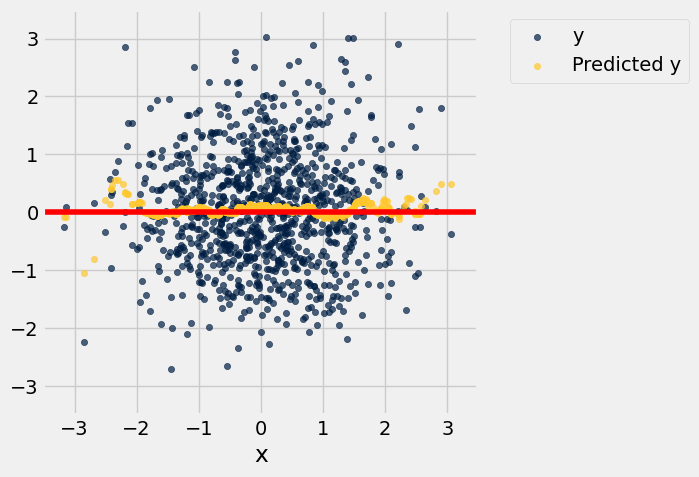

```python
example = example.with_column(
    'Predicted y', example.apply(nn_prediction_example, 'x'))
example.scatter('x')
draw_line(slope = 0)
resize_window()
```

Identify the best fit line in relation to the nearest neighbor predictions with data showing an r value of 0.5.

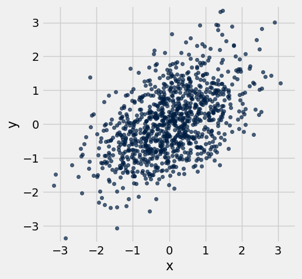

```python
example = r_table(0.5)
example.scatter('x', 'y')
resize_window()
```

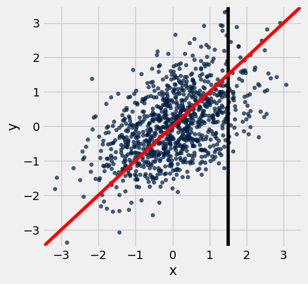

```python
example = r_table(0.5)
example.scatter('x', 'y')
resize_window()
draw_vertical_line(1.5)
draw_line(slope=1, intercept=0)
```

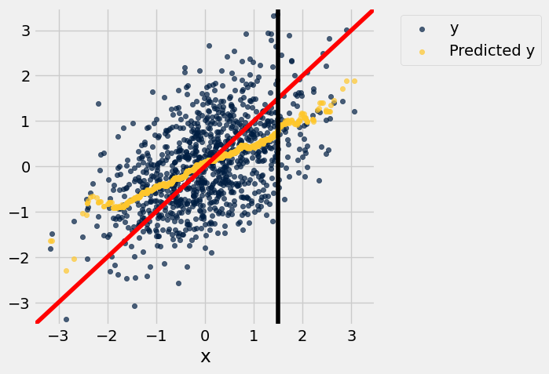

```python
example = example.with_column('Predicted y', example.apply(nn_prediction_example, 'x'))
example.scatter('x')
draw_line(slope=1)
draw_vertical_line(1.5)
resize_window()
```

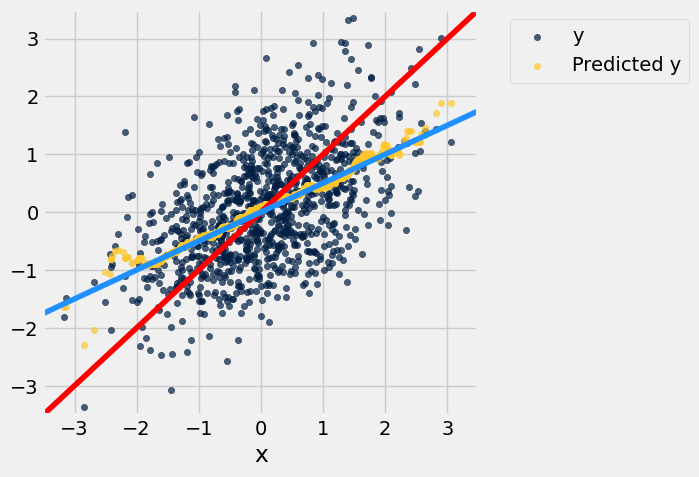

```python
example.scatter('x')
draw_line(slope=1, intercept=0, color='red')
draw_line(slope=0.5, intercept=0, color='dodgerblue')
resize_window()
```

## Linear Regression

### Linear Regression

- A statement about x and y pairs
  - Measured in standard units
  - Describing the deviation of $x$ from 0 (the average of $x$'s)
  - And the deviation of $y$ from 0 (the average of $y$'s)
- On average, $y$ deviates from 0 less than $x$ deviates from 0
- Regression Line Equation: $y_{\text{su}} = r \times x_{\text{su}}$
- Not true for all points — a statement about averages

## Slope & Intercept

### Regression Line Equation

- In original units, the regression line has this equation: $$\frac{\text{estimate of } y - \text{average of } y}{\text{SD of } y} = r \times \frac{\text{the given } x - \text{average of } x}{\text{SD of } x}$$
- Lines can be expressed by slope & intercept as: $y = \text{slope} \times x + \text{intercept}$

### Regression Line

[figure not shown]

Pause for today.

### Slope and Intercept

Typo: `slope * y` should be `slope * x`.

- `estimate_of_y = slope * x + intercept`
- `slope = r * (SD_y / SD_x)`
- `intercept = mean_y - slope * mean_x`

### Demo: Defining the line

Use the `standard_units` and `correlation` functions to define functions `slope` and `intercept`.

```python
# Copy-pasted from above
def standard_units(x):
    """Converts an array x to standard units"""
    return (x - np.mean(x)) / np.std(x)

def correlation(t, x, y):
    x_su = standard_units(t.column(x))
    y_su = standard_units(t.column(y))
    return np.mean(x_su * y_su)
```

```python
def slope(t, x, y):
    '''t is a table, x and y are labels of columns in t.'''
    SD_y = np.std(t.column(y))
    SD_x = np.std(t.column(x))
    r = correlation(t, x, y)
    return r * (SD_y / SD_x)

def intercept(t, x, y):
    mean_y = np.mean(t.column(y))
    mean_x = np.mean(t.column(x))
    the_slope = slope(t, x, y)
    return mean_y - the_slope * mean_x
```

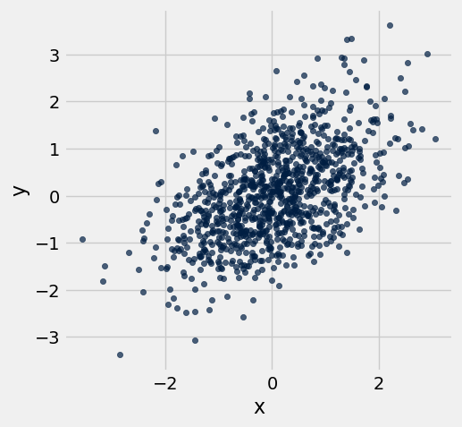

```python
example = r_table(0.5)
example.scatter('x')
```

```python
slope(example, 'x', 'y'), intercept(example, 'x', 'y')
```

```
(0.50226382816259152, 0.038014795445425811)
```

### Reflection

Suppose we use linear regression to predict candy prices (in dollars) from sugar content (in grams). What are the units of each of the following?

- $r$ - No Units!
- The slope - \$/gram
- The intercept - \$

### Example

- A course has a midterm (average 70; standard deviation 10) and a really hard final (average 50; standard deviation 12)
- If the scatter diagram comparing midterm & final scores for students has an oval shape with correlation 0.75, then...
  1. What do you expect the average final score would be for students who scored 90 on the midterm?
  2. How about 60 on the midterm?

```python
def predict_final_score(midterm_score):
    r = 0.75
    mean_x = 70
    mean_y = 50
    SD_x = 10
    SD_y = 12
    the_slope = r * SD_y / SD_x
    the_intercept = mean_y - the_slope * mean_x
    predicted_final_score = the_slope * midterm_score + the_intercept
    return predicted_final_score
```

```python
predict_final_score(90)
```

```
68.0
```

```python
predict_final_score(60)
```

```
41.0
```

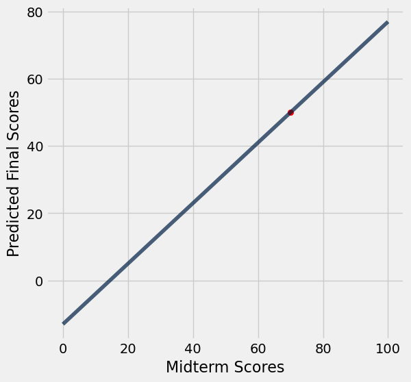

```python
midterm_scores = make_array(0, 100)
predicted_final_scores = predict_final_score(midterm_scores)
tbl = Table().with_columns(
    'Midterm Scores', midterm_scores,
    'Predicted Final Scores', predicted_final_scores
)
tbl.plot('Midterm Scores')
plots.scatter(70, 50, color='red');
```